# ProjetStoehr

tanguyrenaudie

2022-12-11

## Exercice 1

En premier, nous calculons et implémentons les fonctions de répartition et les fonctions de densité.

### I.1

On a les densités suivantes:
$$f(x) =
\frac{1}{\Gamma(\alpha) \theta} x^{\alpha -1} e^{-x / \theta}$$
avec $\alpha = 3$ et $\theta = 2$ et
$$g(y) = \frac{y-\mu + 2b}{4b^2} \mathbb 1_{y \in
[\mu -2b, \mu]} + \frac {1}{2b} e^{-\frac{y-mu}{2b}} \mathbb 1_{y \ge
\mu }$$

On va calculer la fonction de répartition de la variable aléatoire y.

$$G(x)= \left\{
\begin{array}{ll}
\int_{\mu -2b}^{x} \frac{y-\mu + 2b}{4b^2} dy = \frac
{1}{8b^2}(y-\mu+2b)^2& si & x \in [\mu - 2b, \mu] \\
\int_{\mu -2b}^{\mu} \frac{y-\mu + 2b}{4b^2} dy +\int_{\mu
}^{\infty} \frac {1}{2b}
e^{-\frac{y-mu}{2b}}dy = 1-\frac{e^{-\frac{y-mu}{b}}}{2} & si
& x \ge \mu \\
\end{array}
\right.$$
$G$ est bien continue en $\mu$ car
$$\lim\limits_{x \rightarrow \mu^{-}} G(x) =
\lim\limits_{x \rightarrow \mu^{+}} G(x) = \frac{1}{2}$$
Nous remarquons que cette fonction est inversible, d’inverse définie sur $[0,1]$ par

$$G^-1(x)= \left\{
\begin{array}{ll}
\mu -2b + 2b\sqrt{2x} & si & x \in [0,\frac{1}{2}] \\
\mu - b\ln(2(1-x)) & si & x \in [\frac{1}{2}, 1] \\
\end{array}
\right.$$

### I. 2.

Nous allons pouvoir utiliser cette fonction pour simuler selon $Y$ grâce à la méthode de la fonction inverse.

```r
f_density = function(x){
  alpha = 3
  theta = 2
  #shape = alpha , scale = theta
  return( dgamma(x, shape = alpha, scale=theta))
}

F_cumulative <- function(x){
  alpha = 3
  theta = 2
  return(pgamma(x,shape=alpha, scale=theta))
}

g_density = function(y){
  mu = -13
  b = 2
  return( (y>=(mu-2*b) & y<=mu) * (y-mu+2*b)/(4*b^2) +  (y>mu) * 1/(2*b)*exp(-(y-mu)/b) )
}


G_cumulative <- function(y){
  mu = -13
  b = 2

  ret1 <- (y>=(mu-2*b) & y<=mu) *  (1/(8*b^2) * (y-mu+2*b)^2)

  ret2 <- (y>mu) *( 1-exp(-(y-mu)/b)/2)

  return(ret1+ret2)
}
```

```r
#Quelques tests
stopifnot(g_density(-13) == 1/4)
stopifnot(g_density(-17) == 0 )
stopifnot(g_density(-11) ==( 1/4*exp(-1)))
stopifnot(G_cumulative(-17)==0) #mu-2b
stopifnot(G_cumulative(-13)==1/2) #mu
stopifnot(G_cumulative(-11)==1-exp(-1)/2) #mu+b
```

The plots of these functions are correct.

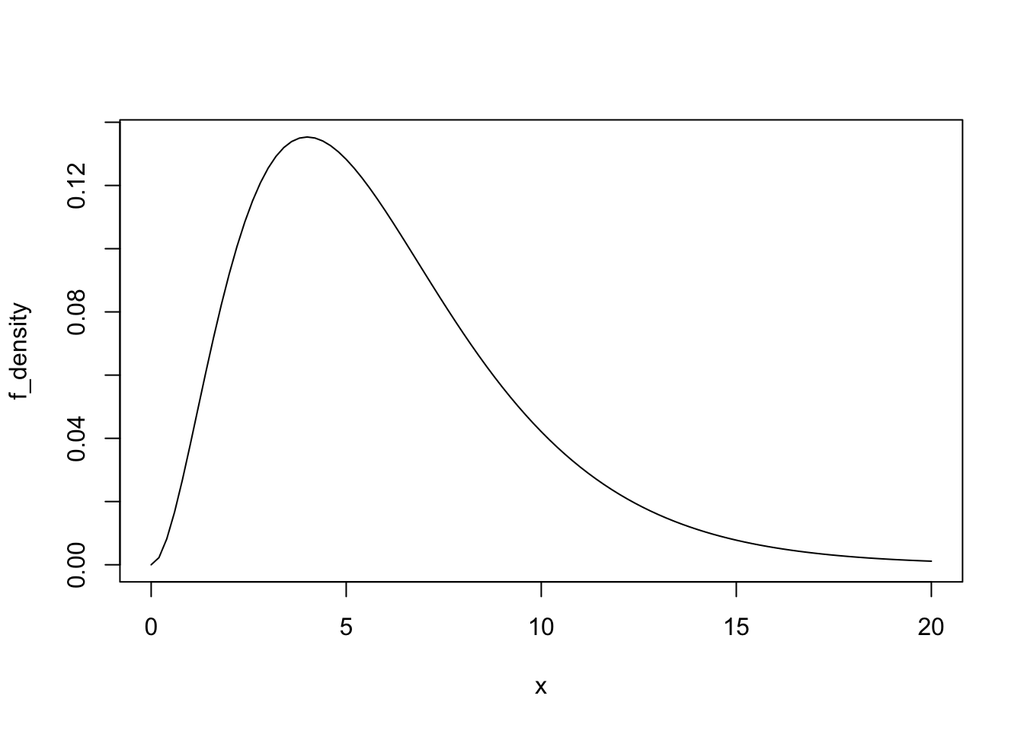

```r
plot(f_density, xlim = c(0,20))
```

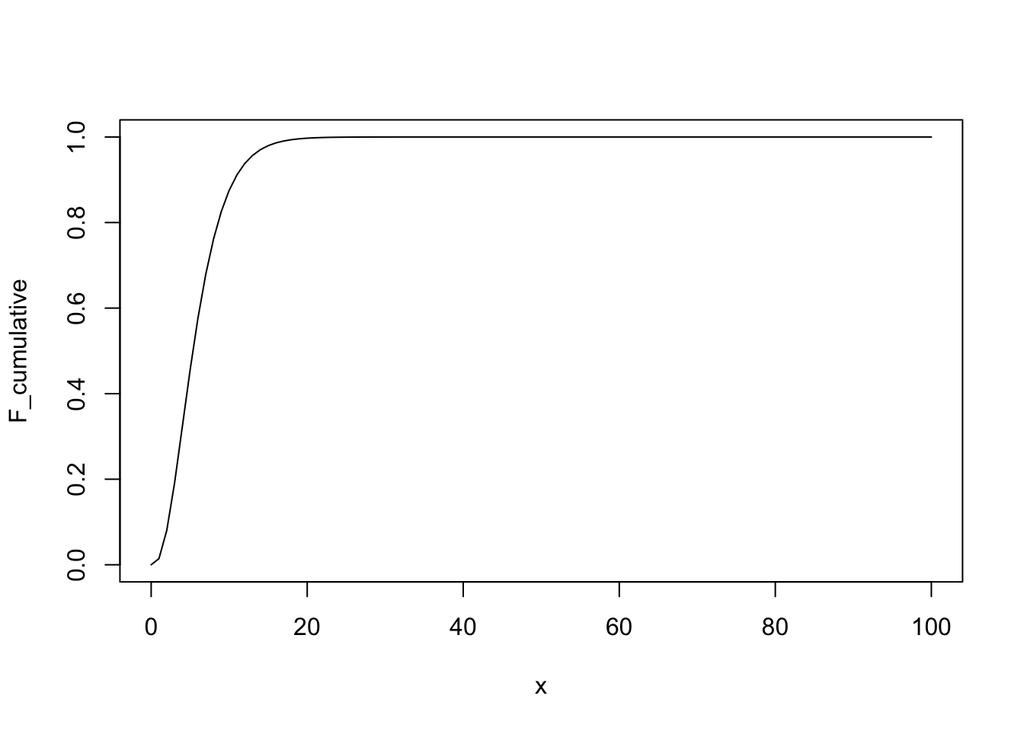

```r
plot(F_cumulative, xlim = c(0,100))
```

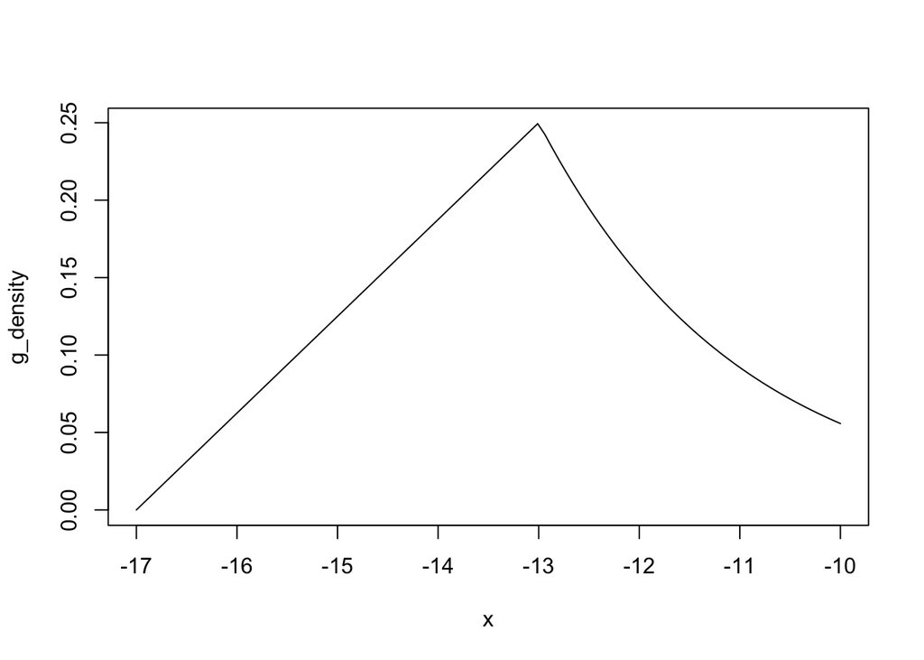

```r
plot(g_density, xlim = c(-17,-10))
```

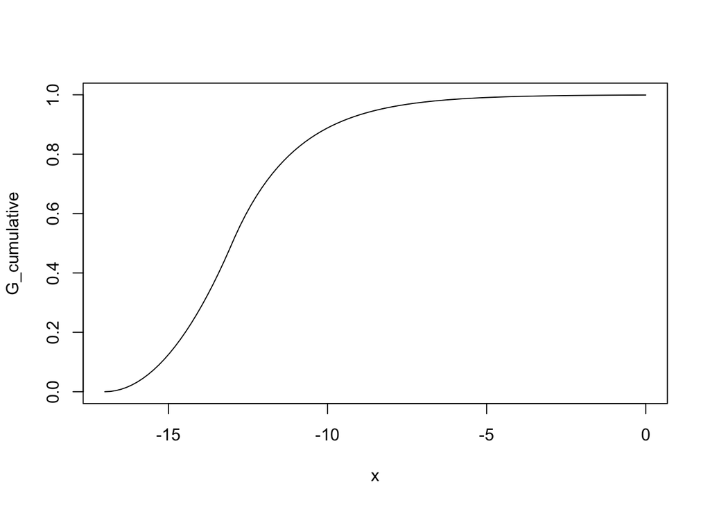

```r
plot(G_cumulative, xlim=c(-17,0))
```

G est bijective entre $\mu-2b$ et $+\infty$

Pour tout $u \in [0,1/2]$ on a $Ginv(u) = \mu - 2b + b\sqrt{8u}$. Donc si $U \to \textbf{U[0,1]}$ alors

Pour tout $u \in ]1/2,1]$, on a:

$$G_{inv}(u) = \mu - b ln(2(1-u))$$

Donc, si $U \to \textbf{U[0,1]}$, comme $1-U \to \textbf{U[0,1]}$,
$$\mu - b ln(2u) \to \textbf{P_Y}$$

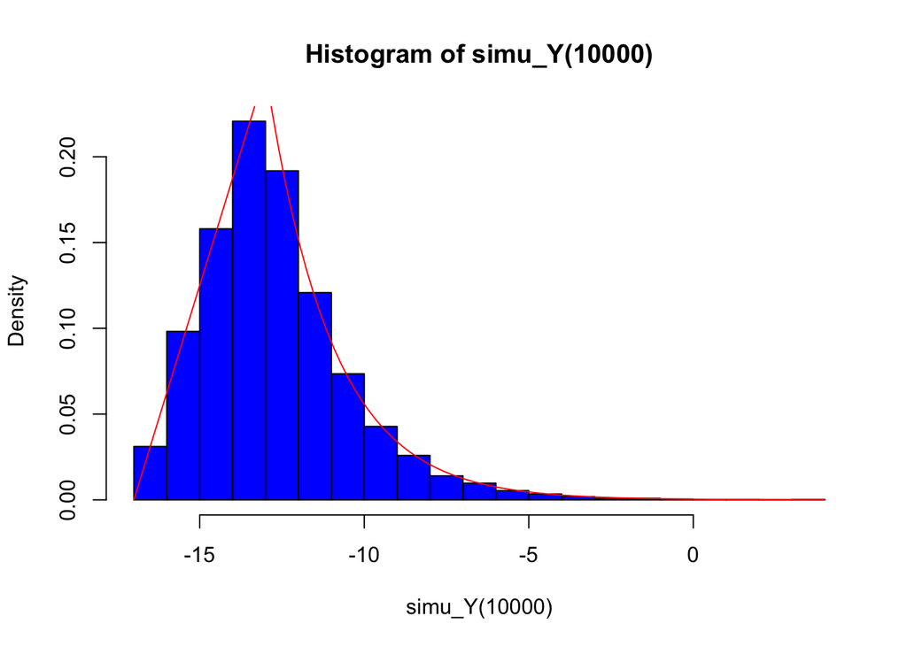

```r
Ginv <- function(u){
  mu = -13
  b = 2
  ret1 <- (u>=0 & u <=1/2) * (mu-2*b+b*sqrt(8*u))
  ret2 <- (u<=1 & u >1/2)  * ( mu-b*log(2*(1-u)))
  return (ret1+ret2)
}


simu_Y <- function(N){

  U = runif(N)
  GinvU = Ginv(U)
  return(GinvU)
}
simu_X <- function(N){
  alpha = 3
  theta = 2
  return(rgamma(N, shape = alpha, scale = theta))
}

hist(simu_Y(10000),  freq= FALSE, breaks = 25, col = 'blue', plot = TRUE)
curve(g_density, add= TRUE, col = 'red')
```

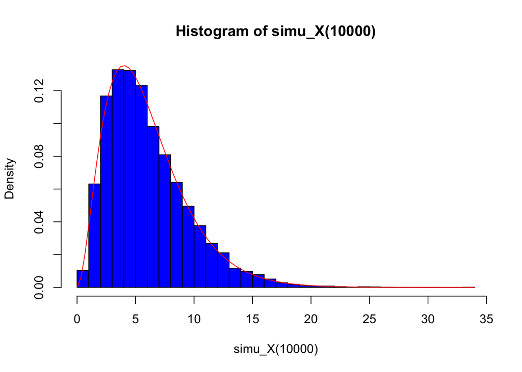

```r
hist(simu_X(10000),  freq= FALSE, breaks = 25, col = 'blue', plot = TRUE)
curve(f_density, add= TRUE, col = 'red')
```

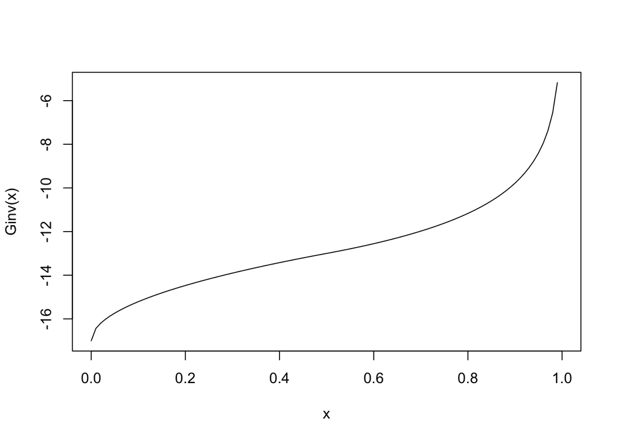

```r
curve(Ginv, xlim = c(0,1))
```

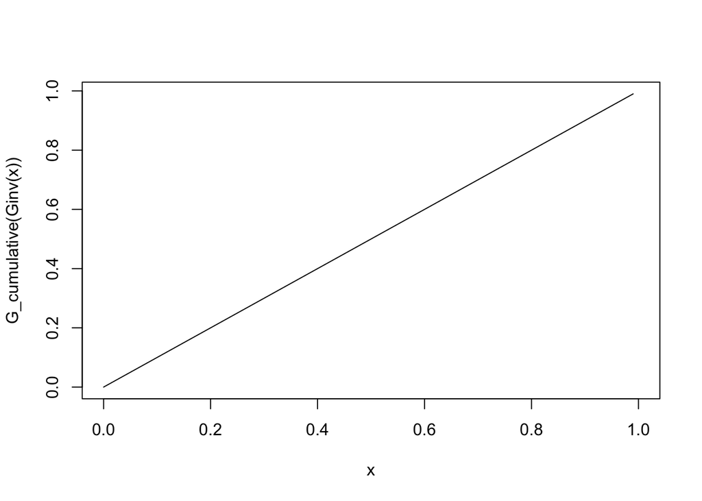

```r
curve(G_cumulative(Ginv(x)), xlim = c(0,1))
```

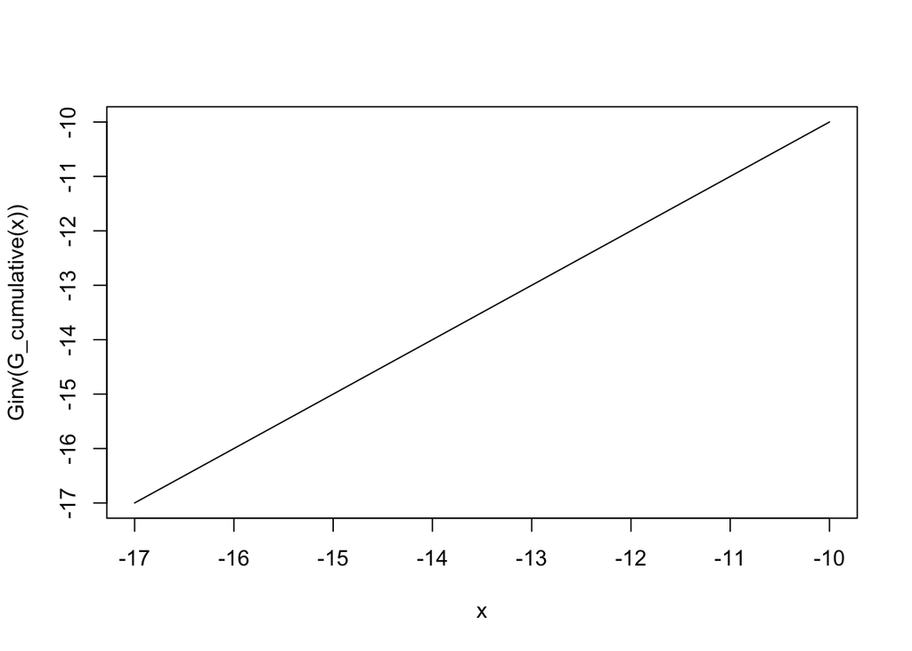

```r
curve(Ginv(G_cumulative(x)), xlim = c(-17,-10))
```

### I.4.

Implémenter un code R qui fournit, pour n = 1000, une estimation de $\delta$

Nous utilisons la méthode de Monte Carlo classique, qui estime l’espérance à partir d’une moyenne empirique. Notons $h_n$ cet estimateur, comme dans le cours.

On pose $h(X,Y) = \mathbf{1}_{X+Y>t}$ Alors, h(X,Y) suit une loi de Bernoulli de paramètre $p = \delta$ Et la variance $\sigma^2$ peut être estimée par:

Par application du théorème central limite, l’intervalle de confiance asymptotique est donné par:
$$IC_{1-\alpha} = [\bar{h_n}-\frac{\sigma
q_{1-\alpha/2}}{\sqrt{n}},\bar{h_n}+\frac{\sigma
q_{1-\alpha/2}}{\sqrt{n}}]$$
Or la variance de h(X) vaut $\delta(1-\delta)$ donc on ne peut pas la calculer directement, il faut l’estimer avec l’estimateur :
$$\hat{\sigma} = \frac{1}{N} \sum_1^N h(X_i)^2 - \delta^2$$

```r
library(glue)
simu4 <- function(N){
  # methode 1: sigma = sommes des carrés/N  - espérance^2
  #question I.4
  s = 0
  s2 = 0


  Y = simu_Y(N)
  X = simu_X(N)
  h = X+Y>0

  esp = 1/N*sum(h)
  var = 1/N * sum(h^2) - esp^2

  alpha = 0.05
  q = qnorm(1-alpha/2)
  margin = sqrt(var)*q/sqrt(N)
  print(glue::glue('Erreur quadratique moyenne:  {(var/N)}' ))
  print(glue::glue("Avec un risque de {alpha}-> resultat :  {esp} +/- {margin}"))
}
simu4(1000)
```

```
## Erreur quadratique moyenne:  5.1975e-05
## Avec un risque de 0.05-> resultat :  0.055 +/- 0.0141301034039237
```

```
est satisfaite.
```

Il suffit de tracer l’erreur quadratique moyenne en fonction du nombre d’itérations

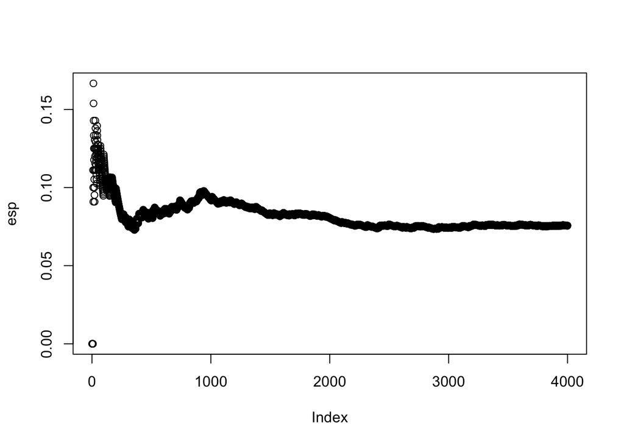

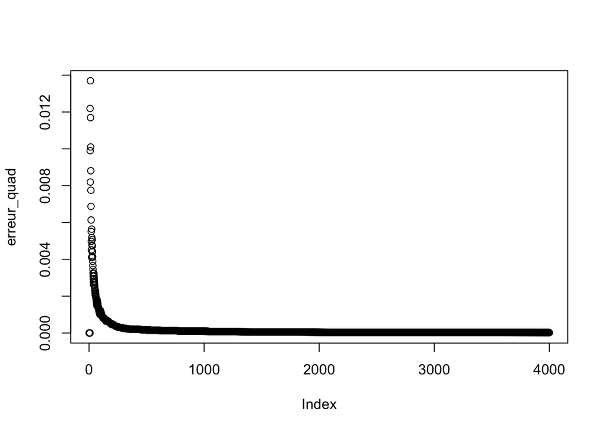

```r
simu_erreur <- function(N){
  # methode 1: sigma = sommes des carrés/N  - espérance^2
  s = 0
  s2 = 0

  Y = simu_Y(N)
  X = simu_X(N)
  h = X+Y>0

  esp = 1/seq(1,N)*cumsum(h)
  var_vector = 1/seq(1,N) * (cumsum(h^2) - esp^2) #pour des Nsim différents : [var(N1), var(N2), var(N3)...]
  erreur_quad = var_vector/seq(1,N)

  plot(esp)
  plot(erreur_quad)

}
simu_erreur(4000)
```

### I.6.

$$\begin{aligned}
\mathbb{E}[1-F(t-Y)] &= \int_\mathbb{R} (1 - F(t-y)) g(y) dy \\
&= \int_\mathbb{R} \int_{t-y}^{\infty}f(x)dx
g(y) dy \\
&= \int_\mathbb{R} \int_\mathbb{R}
\mathbb{1}_{x>t-y}f(x)d(x)g(y)dy \\
&= \int_\mathbb{R^2} \mathbb{1}_{x>t-y}
{\mathbb{dP}_X(x)} \bigotimes \mathbb{dP}_Y(y) \;\; par \, Fubini \\
&= \mathbb{E}[ \mathbb{1}_{X+Y>t}] \\
&= \delta
\end{aligned}$$
En déduire un estimateur $\widehat{\delta}_n$ de $\delta$ utilisant une suite de $n$ variables aléatoires $\left(U_k\right)_{k \geq 1}$ i.i.d. suivant la loi uniforme sur $[0.1]$.

On pose l’estimateur
$$\widehat{\delta}_n = \frac{1}{N} \sum_{i=1}
1-F(t-Y_i)$$
où les $Y_i$ suivent la loi de Y

### I.7

Implémenter un code R qui fournit, pour $n=1000$, l’estimation $\widehat{\delta}_n$, l’erreur quadratique moyenne de $\widehat{\delta}_n$ et un intervalle de confiance asymptotique bilatère pour $\delta$ au niveau $95 \%$.

```r
simu7 <- function(N){
  #question I.7
  # methode 1: sigma = sommes des carrés/N  - espérance^2
  s = 0
  s2 = 0

  Y = simu_Y(N) #ici, interviennent les U_i, par méthode de la fonction inverse
  h = 1- F_cumulative(-Y) #rappelons que t = 0



  esp = 1/N*sum(h)
  var = 1/N * sum(h^2) - esp^2

  alpha = 0.05
  q = qnorm(1-alpha/2)
  margin = sqrt(var)*q/sqrt(N)
  print(glue::glue('Erreur quadratique moyenne:  {(var/N)}' ))
  print(glue::glue("Avec un risque de {alpha}-> resultat :  {esp} +/- {margin}"))
}
#qs = (Ginv(c(0,0.1,0.3,0.4,0.5,0.7,0.9,0.99)))
simu7(1000)
```

```
## Erreur quadratique moyenne:  1.25124211256599e-05
## Avec un risque de 0.05-> resultat :  0.0738297242641327 +/- 0.00693296116399086
```

### I.8.

En fait, on a toujours une variance inférieure pour cet estimateur, car:

$$\begin{aligned}
& \operatorname{Var} \hat{\delta}_n \leqslant
\operatorname{Var}\left(\hat{p}_n\right) \\
& \Leftrightarrow \frac{\operatorname{Var}(1-F(t-y))}{n} \leqslant
\frac{\operatorname{Var}\left(\mathbb{1}_{x+y \lambda t}\right)}{n} \\
& \Leftrightarrow \mathbb{E}\left[(1-F(t-y))^2\right]-\delta^2
\leqslant \delta-\delta^2 \\
& \Leftrightarrow \mathbb{E}\left[(1-F(t-y))^2\right] \leqslant
\delta=\mathbb{E}[1-F(t-y)]
\end{aligned}$$

### I.9.

On pose
$$\begin{aligned}
h \colon &\,\mathbb{R^2} \to \mathbb{R}\\
& y \mapsto 1-F(t-y)
\end{aligned}$$

En utilisant la méthode de la variable antithétique, proposer un estimateur $\widehat{\delta}_n^{\mathrm{A}}$ de $\delta$. Montrer que $\operatorname{Var}\left[\widehat{\delta}_n^{\mathrm{A}}\right] \leq$ $\operatorname{Var}\left[.\widehat{\delta}_n\right]$

Nous remarquons tout simplement que si U suit une loi uniforme sur [0,1], alors 1-U suit également une loi uniforme sur [0,1] . Or, on utilise des $U_i$ pour générer les $Y_i$ de loi de densité g.

Donc il suffit de choisir comme variable antithétique $Y' = G_{inv}(1-U) \to \mathbb{P}_Y$

On pose donc:

$$U \to \mathbb{\mathbb{U}[0,1]}\\
Y = G_{inv}(U) \to \mathbb{P_Y} \\
Y' = G_{inv}(1-U) \to \mathbb{P_Y}$$
Le nouvel estimateur est alors:
$$\widehat{\delta}_n^{\mathrm{A}} = \frac{1}{2N} \sum_{i=1}^N h(Y_i)+
h(Y_i')$$
La variance de cet estimateur vaut
$$\begin{aligned}
Var(\widehat{\delta}_n^{\mathrm{A}})
& = \frac{1}{4N} Var(h(Y)+ h(Y')) \\
&= \frac{1}{4N} (Var(h(Y) + Var(h(Y') + 2Cov(h(Y),h(Y')) \\
&= \frac{1}{4N} (2Var(h(Y) + 2Cov(h(Y),h(Y')) \\
&= \frac{1}{2N} (Var(h(Y) + Cov(h(Y),h(Y')) \\
\end{aligned}$$
Il suffit de montrer que $Cov(h(Y),h(Y’)) < 0 $ pour montrer que le nouvel estimateur est au moins efficace que $\bar{h}_{2n}$.

Or, on sait que h est une fonction croissante de sa variable y, et que la transformation antithétique subie par U pour donner Y’ est décroissante. Donc
$$Cov(h(Y), h(Y')) \le 0$$

Donc
$$Var(\widehat{\delta}_n^{\mathrm{A}}) \le
Var(\bar{h}_n)$$

### I.10.

Implémenter un code R qui fournit, pour $n=1000$, l’estimation $\widehat{\delta}_n^{\mathrm{A}}$, l’erreur quadratique moyenne de $\widehat{\delta}_n^{\mathrm{A}}$ et un intervalle de confiance asymptotique bilatère pour $\delta$ au niveau $95 \%$.

```r
simu10 <- function(N){
  #q.I.10
  alpha = 3
  theta = 2


  U = runif(N)
  Y = Ginv(U) #ici, interviennent les U_i
  Y2 = Ginv(1-U)
  h = (1 - F_cumulative(-Y) + 1-F_cumulative(-Y2))/2 #rappelons que t = 0




  esp = 1/N*sum(h)
  var = 1/N * sum(h^2) - esp^2

  alpha = 0.05
  q = qnorm(1-alpha/2)
  margin = sqrt(var)*q/sqrt(N)
  print(glue::glue('Erreur quadratique moyenne:  {(var/N)}' ))
  print(glue::glue("Avec un risque de {alpha}-> resultat :  {esp} +/- {margin}"))
}
simu10(1000)
```

```
## Erreur quadratique moyenne:  3.39291597918511e-06
## Avec un risque de 0.05-> resultat :  0.0701836874158635 +/- 0.00361022811136841
```

On voit que l’erreur quadratique moyenne est plus de deux fois plus faible! Cete estimateur est donc bien plus efficace, en effet.

### I.11

Entre $h_{0,1}$ et $h_{0,2}$, quelle fonction utiliseriez-vous pour réduire la variance de $\widehat{\delta}_n$ à l’aide de la méthode de la variable de contrôle? Écrire l’estimateur $\widehat{\delta}_n^{\text {cont }}$ associé.

Pour la méthode de variable de contrôle, il nous faut une variable aléatoire auxiliaire $h_0(Y)$ dont on capable de calculer exactement l’espérance, disons $m$.

Comme $E(h(Y)) = E(h(Y) - h_0(Y)) + m$, en ajoutant un paramètre $b$ à optimiser, l’estimateur correspondant:
$$\widehat{\delta}_n^{cont}= \frac{1}{N} \sum_{i=1}^N h(Y_i) - b(h_0(Y_i)
- m)$$
Donc entre h_{0,1} et h_{0,2}, comme il n’est pas possible de calculer la valeur exacte de $P(Y \ge t - q_\epsilon)$, il est préférable d’utiliser $h_{0,1}$

Calculons E(Y)

$$
$$\begin{aligned}
\mathbb{E}(Y)
&= \int_{u-2b}^\mu y \frac{y-\mu + 2b}{4b^2} dy + \int_{\mu}^\infty
y \frac{exp(-\frac{y-\mu}{b})}{2b}dy \\
&= \int_{u-2b}^\mu (y-\mu+2b) \frac{y-\mu+2b}{4b^2} dy +
\int_{\mu-2b}^\mu (\mu-2b) \frac{y-\mu+2b}{4b^2} dy +
\int_{\mu}^\infty y \frac{exp(-\frac{y-\mu}{b})}{2b}dy \\
&= \left[\frac{(y-\mu+2b)^3}{12b^2}\right]_{\mu-2b}^\mu +
\frac{\mu-2b}{4b^2}\left[\frac{(y-\mu+2b)^2}{2}\right]_{\mu-2b}^\mu
+ \left[-\frac{y}{2}exp(-\frac{y-\mu}{b})\right] _\mu^\infty +
\frac{1}{2} \int_\mu^\infty exp(-\frac{y-\mu}{b})dy \\
&= \frac{8b^3}{12b^2} + \frac{4b^2(\mu-2b)}{8b^2} + \frac{\mu+b}{2}
\\
&= \frac{2b}{3} + \frac{\mu-2b}{2} + \frac{\mu+b}{2} \\
&= \mu +b/6 \\
&= -(12+2/3)
\end{aligned}$$

$$

Verifions ce calcul.

```r
f_int2 <- function(y){
  return(exp(-(y+13)/2))
}
integrate(f_int2,lower=-13,upper = 1000)
```

```
## 2 with absolute error < 2.4e-09
```

```r
espY <- function(N){
  U = runif(N)
  mu = -13
  Y = Ginv(U) #ici, interviennent les U_i
  Y2 = Ginv(1-U)
  h = (Y+Y2)/2  #rappelons que t = 0




  esp = 1/N*sum(h)
  var = 1/N * sum(h^2) - esp^2

  alpha = 0.05
  q = qnorm(1-alpha/2)
  margin = sqrt(var)*q/sqrt(N)
  print(glue::glue('Erreur quadratique moyenne:  {(var/N)}' ))
  print(glue::glue("Avec un risque de {alpha}-> resultat :  {esp} +/- {margin}"))
}
espY(100000)
```

```
## Erreur quadratique moyenne:  3.41075515814964e-06
## Avec un risque de 0.05-> resultat :  -12.6640784892185 +/- 0.00361970654715295
```

```r
b = 2
mu = -13
esp_theorique = -(12+2/3)
print("esp_theorique : ")
```

```
## [1] "esp_theorique : "
```

```r
print(esp_theorique)
```

```
## [1] -12.66667
```

### I.12.

On a bien calculé l’espérance théorique de Y, notée m dans le code ci-dessous. Maintenant, faisons la simulation de $\delta$ par variable de contrôle $h_{0,1}(Y) = Y$

```r
simu12 <- function(N){
  #question I. 12
  alpha = 3
  theta = 2
  b = 1
  m = -(12+2/3)

  U = runif(N)
  Y = Ginv(U) #ici, interviennent les U_i
  h = 1 - F_cumulative(-Y) - b*Y

  moy = 1/N*sum(h)
  esp = moy + b*m
  var = 1/N * sum(h^2) - moy^2

  alpha = 0.05
  q = qnorm(1-alpha/2)
  margin = sqrt(var)*q/sqrt(N)
  print(glue::glue('Erreur quadratique moyenne:  {(var/N)}' ))
  print(glue::glue("Avec un risque de {alpha}-> resultat :  {esp} +/- {margin}"))
}
simu12(1000)
```

```
## Erreur quadratique moyenne:  0.00462811361676859
## Avec un risque de 0.05-> resultat :  0.0495451461517575 +/- 0.133336821157212
```

### I.13

Montrons que
$$\begin{aligned}
& {Var}\left[\widehat{\delta}_n(\beta)\right]=\mathbb{V a
r}\left[\widehat{\delta}_n\right]-\frac{1}{n}(2<\beta,
C>-<\beta, \Sigma \beta>), \quad \text { avec } \\
& C=\left(\begin{array}{c}
{Cov}[F(t-Y), Y] \\
{Cov}\left[F(t-Y), \mathbb{1}_{\left\{Y \geq
t-q_{\varepsilon}\right\}}\right]
\end{array}\right) \text { et } \quad \Sigma=\left(\begin{array}{cc}
\mathbb{V a r}[Y] & {Cov}\left[Y, \mathbb{1}_{\left\{Y \geq
t-q_{\varepsilon}\right\}}\right] \\
{Cov}\left[Y, \mathbb{1}_{\left\{Y \geq
t-q_{\varepsilon}\right\}}\right] & \mathbb{V a
r}\left[\mathbb{1}_{\left\{Y \geq t-q_{\varepsilon}\right\}}\right]
\end{array}\right) .
\end{aligned}$$
$$\widehat{\delta}_n(\beta)=1-\frac{1}{n} \sum_{k=1}^n
F\left(t-Y_k\right)-<\beta,\left(\begin{array}{c}
Y_k-\mathbb{E}[Y] \\
\mathbb{1}_{\left\{Y_k \geq t-q_{\varepsilon}\right\}}-\mathbb{P}\left[Y
\geq t-q_{\varepsilon}\right]
\end{array}\right)>$$
L’estimateur est composé d’une constante, puis d’une moyenne des variables aléatoires du type:

$$F\left(t-Y_k\right)-<\beta,\left(\begin{array}{c}
Y_k-\mathbb{E}[Y] \\
\mathbb{1}_{\left\{Y_k \geq t-q_{\varepsilon}\right\}}-\mathbb{P}\left[Y
\geq t-q_{\varepsilon}\right]
\end{array}\right)>$$

Et ces variables aléatoires sont i.i.d, car les $Y_k$ le sont.

donc, par les propriétés de la variance, on obtient:
$$Var(\widehat{\delta}_n(\beta))=
\frac{1}{n} Var\left[F(t-Y) - \beta_1 (Y_k - \mathbb{E}[Y]) - \beta_2(
\mathbb{1}_{Y_k \geq t-q_\varepsilon} - \mathbb{P}\left(Y \geq
t-q_{\varepsilon} \right)\right]$$

$$\begin{aligned}
{Var}\left[\widehat{\delta}_n(\beta)\right]
&=\frac{1}{n} Var\left[F(t-Y) - \beta_1 (Y - \mathbb{E}[Y]) -
\beta_2( \mathbb{1}_{Y \geq t-q_\varepsilon} - \mathbb{P}\left(Y \geq
t-q_{\varepsilon} \right)\right] \\
&=\frac{1}{n} Var\left[F(t-Y)\right] + \beta_1^2 Var(Y) + \beta_2^2
Var( \mathbb{1}_{Y\geq t-q_\varepsilon}) -2\beta_1Cov(F(t-Y),Y)
-2\beta_2Cov(F(t-Y), \mathbb{1}_{(Y \geq t-q_\varepsilon)}) +
2\beta_1\beta_2 Cov(Y,\mathbb{1}_{(Y \geq t-q_\varepsilon)}) \\
&=\frac{1}{n} Var\left[F(t-Y)\right]-2\beta_1Cov(F(t-Y),Y)
-2\beta_2Cov(F(t-Y), \mathbb{1}_{(Y \geq t-q_\varepsilon)}) + \beta_1^2
Var(Y) + \beta_2^2 Var( \mathbb{1}_{Y\geq t-q_\varepsilon}) +
2\beta_1\beta_2 Cov(Y,\mathbb{1}_{(Y \geq t-q_\varepsilon)}) \\
&=
\mathbb{Var}\left[\widehat{\delta}_n\right]-\frac{1}{n}(2<\beta,
C>-<\beta, \Sigma \beta>) \\
&\text{où le premier terme donne }
\mathbb{Var}\left[\widehat{\delta}_n\right]\\
&\text{et où les deux suivants donnent} <\beta, C> \\
&\text{et où les trois derniers donnent}<\beta, \Sigma \beta>
\\
\end{aligned}$$

```r
print("q_esp : ")
```

```
## [1] "q_esp : "
```

```r
print(qgamma(0.6, shape = 3 , scale= 2)) #qeps = 6.21
```

```
## [1] 6.210757
```

### I.14

Calculer explicitement $\Sigma$ et vérifier qu’elle est inversible

Nous voyons que le quantile d’ordre 0.6 de X est inférieur à 6.3. Donc $t-q_\epsilon \gt \mu$ Posons $p = P(Y \geq t-q_{\varepsilon}), m = \mathbb{E}(Y) = -(12+2/3)$ On calcule, d’abord, la probabilité p:

$$\begin{aligned}
p &= \mathbb{P}(Y\ge q_\epsilon) \\
&= \int_{-q_\epsilon}^\infty \frac{1}{2b} exp(-\frac{y-\mu}{b})dy \\
&= \frac{1}{2} exp(\frac{q_\epsilon+\mu}{b})
\end{aligned}$$

Il suit,
$$\begin{aligned}
Cov\left[Y, \mathbb{1}_{\left\{Y \geq t-q_{\varepsilon}\right\}}\right]
&= \mathbb{E}((Y - m )(\mathbb{1}_{\left\{Y \geq
t-q_{\varepsilon}\right\}} - p) ) \\
&= \mathbb{E}(Y\mathbb{1}_{(Y \geq t-q_{\varepsilon})}) - mp
\end{aligned}$$
Par suite,
$$\begin{aligned}
\mathbb{E}(Y\mathbb{1}_{(Y \geq t-q_{\varepsilon})})
&= \int_{t-q_\epsilon}^\infty \frac{y}{2b} exp(-\frac{y-\mu}{b})dy
\\
&=
\left[-\frac{y}{2}exp(-\frac{y-\mu}{b})\right]_{t-q_\epsilon}^\infty+
\int_{t-q_\epsilon}^\infty \frac{1}{2} exp(-\frac{y-\mu}{b})dy \\
&= -q_\epsilon exp(\frac{q_\epsilon+\mu}{b})+
\int_{t-q_\epsilon}^\infty \frac{1}{2} exp(-\frac{y-\mu}{b})dy \; \text
{ avec (t = 0)} \\
&= -q_\epsilon/2 exp(\frac{q_\epsilon+\mu}{b}) -b/2
exp(\frac{q_\epsilon+\mu}{b})\\
&= - \frac{q_\epsilon+\mu}{2} exp(\frac{q_\epsilon+\mu}{b}) \\
\end{aligned}$$
et enfin,
$$\begin{aligned}
Cov\left[Y, \mathbb{1}_{\left\{Y \geq t-q_{\varepsilon}\right\}}\right]
&= \mathbb{E}(Y\mathbb{1}_{(Y \geq t-q_{\varepsilon})}) - mp \\
&= - \frac{q_\epsilon+\mu}{2} exp(\frac{q_\epsilon+\mu}{b}) - mp
\end{aligned}$$
En outre,

$$Var(\mathbb{1}_{(Y \geq t-q_{\varepsilon})}) = p(1-p) \text{ (loi de
Bernoulli de paramètre p)}$$
Enfin le calcul de $Var(y)$ se fait en deux étapes:

$$\begin{aligned}
Var(Y) &= \mathbb{E}(Y^2) - m^2 \\
&= \int_{\mu-2b}^\mu \frac{y-\mu+2b}{4b^2} y^2 dy + \int_\mu^\infty
\frac{1}{2b} exp(-\frac{y-\mu}{b})dy - m^2 \\
\end{aligned}$$
Pour la première intégrale,

$$\begin{aligned}
\int_{\mu-2b}^\mu \frac{y-\mu+2b}{4b^2} y^2 dy
&= \int_{\mu-2b}^\mu \frac{y-\mu+2b}{4b^2} (y-\mu+2b + (\mu - 2b))^2
dy \\
&= \int_{\mu-2b}^\mu \frac{y-\mu+2b}{4b^2} (y-\mu+2b)^2 dy +
\int_{\mu-2b}^\mu \frac{y-\mu+2b}{4b^2} (\mu-2b)^2 dy +
2 \int_{\mu-2b}^\mu \frac{(y-\mu+2b)^2}{4b^2} (\mu-2b) dy \\
&= \frac{1}{4b^2}\left[(y-\mu+2b)^4/4\right]_{\mu-2b}^\mu +
\frac{(\mu-2b)^2}{4b^2} \left[(y-\mu+2b)^2/2\right]_{\mu-2b}^\mu +
2\frac{\mu-2b}{4b^2} \left[(y-\mu+2b)^3/3\right]_{\mu-2b}^\mu \\
&= \frac{16b^4}{16b^2} +
\frac{(\mu-2b)^2 *4b^2}{2*4b^2} +
2\frac{(\mu-2b)8b^3}{3*4b^2} \\
&= b^2 +
\frac{(\mu-2b)^2}{2} +
\frac{(\mu-2b)4b}{3} \\
&= 4 +
\frac{17^2}{2} +
\frac{17*8}{3} \\
&= 4 +
289/2 +
136/3 \\
&= 103+1/6\\
\end{aligned}$$

Nous pouvons vérifier avec une simple intégration sur R. Nous aurions faire une intégration de type Monte Carlo également.

```r
fy <- function(y){(y+17)*y^2/16}
integrate(f=fy,lower=-17, upper = -13)
```

```
## 103.1667 with absolute error < 1.1e-12
```

Pour la deuxième intégrale,

$$
$$\begin{aligned}
\int_{\mu}^\infty y^2 \frac{exp(-\frac{y-\mu}{b})}{2b}dy
&= \left[-\frac{y^2}{2}exp(-\frac{y-\mu}{b})\right] _\mu^\infty +
\int_{\mu}^\infty y exp(-\frac{y-\mu}{b})dy \\
&=\frac{\mu^2}{2} + \left[-byexp(-\frac{y-\mu}{b})\right]
_\mu^\infty + \int_{\mu}^\infty b exp(-\frac{y-\mu}{b})dy \\
&=\frac{\mu^2}{2} + b(\mu+b)\\
&= 169/2 - 22\\
&= 125/2
\end{aligned}$$

$$ Nous pouvons encore une fois vérifier avec une simple intégration sur R

```r
fy <- function(y){exp(-(y+13)/2)*y^2/4}
integrate(f=fy,lower=-13, upper = 1000)
```

```
## 62.5 with absolute error < 3.1e-06
```

Expression de la variance:

$$\begin{aligned}
Var(Y)
&= \int_{\mu-2b}^\mu \frac{y-\mu+2b}{4b^2} y^2 dy + \int_\mu^\infty
\frac{1}{2b} exp(-\frac{y-\mu}{b})dy - m^2 \\
&= b^2 +
\frac{(\mu-2b)^2}{2} +
\frac{(\mu-2b)4b}{3} + \frac{\mu^2}{2} + b(\mu+b) - (\mu +b/6)^2 \\
&= \frac{47}{36}b^2 \\
&\simeq 5.22
\end{aligned}$$

```r
varY <- function(N){
  U = runif(N)
  mu = -13
  Y = Ginv(U) #ici, interviennent les U_i
  Y2 = Ginv(1-U)
  h = Y  #rappelons que t = 0


  esp = 1/N *sum(h)
  var = 1/N * sum(h^2) - esp^2

  alpha = 0.05
  q = qnorm(1-alpha/2)
  margin = sqrt(var)*q/sqrt(N)
  print(glue::glue('Estimation de la variance:  {(var)}' ))
}
varY(10000)
```

```
## Estimation de la variance:  4.99506813597966
```

```r
b = 2
mu = -13
```

$$Z = \left(
\begin{array}{c}
Y\\
\mathbb{1}_{\left\{Y \geq t-q_{\varepsilon}\right\}}
\end{array}
\right)$$

### I.15.

$$\begin{aligned}
\operatorname{Var}\left[\widehat{\delta}_n\left(\beta^{\star}\right)\right]
&=
\mathbb{Var}\left[\widehat{\delta}_n\right]-\frac{1}{n}(2<\beta^{\star},
C>-<\beta^\star, \Sigma \beta^{\star}>) \leq
\mathbb{Var}\left[\widehat{\delta}_n\right] \\
&\Longleftrightarrow 2<\beta^{\star}, C>-<\beta^{\star},
\Sigma \beta^{\star}\ge 0 \\
&\Longleftrightarrow
2C^T\Sigma^{-1}C-C^T\Sigma^{-1}\Sigma\Sigma^{-1}C \ge 0 \text{ car }
\Sigma \text{ est symétrique} \\
&\Longleftrightarrow C^T\Sigma^{-1}C \ge 0 \\
\end{aligned}$$

Or $\Sigma$ est symétrique positive donc son inverse l’est aussi et cette dernière inégalité est vérifiée.

### I. 16

Posons $\hat{\delta}_n^{cont2}$ un estimateur r basé sur la méthode de la variable de contrôle utilisant $h_0:y \mapsto h_{0,1}(y)+h_{0,2}(y)$. Nous allons comparer cet estimateur à $\widehat{\delta}_n\left(\beta^{\star}$ Cet estimateur vaut:

$$\begin{aligned}
\hat{\delta}_n^{cont2} &= \frac{1}{n}\sum_{k=1}^n 1-F(t-Y_k) -
b(h_{0,1}(Y_k)+h_{0,2}(Y_k) - E\left[h_{0,1}(Y)+h_{0,2}(Y)\right] ) \\
&= \frac{1}{n}\sum_{k=1}^n 1- F(t-Y_k) - b(Y_k-\mathbb{E}(Y_k) ) -
b( \mathbb{1}_{\left\{Y \geq t-q_{\varepsilon}\right\}} -
\mathbb{P}(Y\ge t-q_\epsilon))
\end{aligned}$$
On peut directement voir que cet estimateur, comme somme de variables iid, a comme espérance, par linéarité de l’espérance:
$$\begin{aligned}
\mathbb{E}(\hat{\delta}_n^{cont2}) &= \mathbb{E}(1-F(t-Y)) -
b\mathbb{E}[Y_k-\mathbb{E}(Y_k)] - b\mathbb{E}[\mathbb{1}_{\left\{Y \geq
t-q_{\varepsilon}\right\}} - \mathbb{P}(Y\ge t-q_\epsilon)] \\
&= \mathbb{E}(1-F(t-Y)) \\
&= \delta \text{ d'après la questions I.6.}
\end{aligned}$$
Donc cet etimateur est sans biais, tout comme $\hat{\delta}_n(\beta^{\star})$. Nous allons donc calculer sa variance et montrer qu’elle est plus élevée que celle de $\hat{\delta}_n(\beta^{\star})$. Posons, $f_{var} : (\beta_1,\beta_2) \in \mathbb{R}^2 \mapsto \frac{1}{n} Var\left[F(t-Y) - \beta_1 (Y - \mathbb{E}[Y]) - \beta_2( \mathbb{1}_{Y \geq t-q_\varepsilon} - \mathbb{P}\left(Y \geq t-q_{\varepsilon} \right)\right]$
$$\begin{aligned}
\forall \beta \in \mathbb{R},
{Var}(\hat{\delta}_n^{cont2}(\beta)) &=\frac{1}{n} Var\left[F(t-Y) -
\beta (Y - \mathbb{E}[Y]) - \beta( \mathbb{1}_{Y \geq t-q_\varepsilon} -
\mathbb{P}\left(Y \geq t-q_{\varepsilon} \right)\right] \\
&\text{on reconnait la fonction fvar, restreinte à la droite R(1,1)}
\\
Or\;\; min_{\beta \in \mathbb{R}(1,1)} f_{var}(\beta)
&\leq min_{\beta \in \mathbb{R}^2} f_{var}(\beta) \\
Donc\;\; min_{\beta \in \mathbb{R}} Var(\hat{\delta}_n^{cont2}(\beta))
&\leq min_{(\beta_1,\beta_2) \in \mathbb{R}^2}
\operatorname{Var}\left[\widehat{\delta}_n\left(\beta_1,\beta_2\right)\right] =
\operatorname{Var}\left[\widehat{\delta}_n\left(\beta^{\star}\right)\right]
\end{aligned}$$
Donc, l’estimateur $\widehat{\delta}_n\left(\beta^{\star}\right)$ est préférable en terme de variance à un estimateur basé sur la méthode de la variable de contrôle utilisant $h_0: y \mapsto h_{0,1}(y)+h_{0,2}(y)$ .

### I.17.

```r
simu17 <- function(N){
  #question 17
  #constantes
  alpha = 3
  theta = 2
  b = 2
  m = -(12+2/3) #E(Y)
  qeps = qgamma(0.6,shape = alpha, scale = theta)
  p = 0.5 * exp((qeps + mu)/b)

  U = runif(N)
  Y = Ginv(U) #ici, interviennent les U_i
  FY = F_cumulative(-Y)
  EY = m
  EF = 1/N * sum(FY)
  CovFY = 1/N*sum(FY*Y) -  EF*EY
  CovY1 = 1/N * sum(Y*(Y>=qeps)) - EY*p
  CovF1 = 1/N * sum(FY*(Y>=qeps)) - EF*p
  VarY = 1/N *sum(Y^2) - EY^2
  Var1 = p*(1-p)
  Sigma = matrix(data = c(VarY, CovY1,CovY1,Var1), nrow = 2)
  C = matrix(data = c(CovFY,CovF1), nrow = 2)
  print(Sigma)
  print(C)
  print("je n'ai pas fini cette question.")
  print("mais j'aurais aimé faire la stratégie 2 du cours, où l'on simule b* avec tout l'échantillon, avant de simuler l'estimateur, quitte à avoir un estimateur biaisé à la fin. ")
}
simu17(100)
```

```
##           [,1]       [,2]
## [1,] 1.4627830 0.21250395
## [2,] 0.2125039 0.01649517
##             [,1]
## [1,] -0.05748067
## [2,] -0.01556404
## [1] "je n'ai pas fini cette question."
## [1] "mais j'aurais aimé faire la stratégie 2 du cours, où l'on simule b* avec tout l'échantillon, avant de simuler l'estimateur, quitte à avoir un estimateur biaisé à la fin. "
```

### I.18

18. Soit $h \in L^2([0,1])$. Montrer que pour une suite $\left(U_k\right)_{k \geq 1}$ de variables aléatoires $i.i.d$. de loi uniforme sur [0,1], on a
    $${Var}\left[\frac{1}{n} \sum_{k=1}^n
    h\left(\frac{k-1+U_k}{n}\right)\right] \leq {Var}\left[\frac{1}{n}
    \sum_{k=1}^n h\left(U_k\right)\right]$$

On a:
$$\begin{aligned}
{Var}\left[\frac{1}{n} \sum_{k=1}^n
h\left(\frac{k-1+U_k}{n}\right)\right]
&= \frac{1}{n^2} \sum_{k=1}^n Var \left[
h\left(\frac{k-1+U_k}{n}\right) \right ] \\
&= \frac{1}{n^2} \sum_{k=1}^n \mathbb{E}\left[h\left(\frac{k-1+U_k}{n}\right)^2\right]
-
\mathbb{E}\left[h\left(\frac{k-1+U_k}{n}\right)\right]^2 \\
&= \frac{1}{n^2} \sum_{k=1}^n
\int_0^1 h\left(\frac{k-1+x}{n}\right)^2dx -
\left[\int_0^1 h\left(\frac{k-1+x}{n}\right)dx\right]^2 \\
&= \frac{1}{n^2} \sum_{k=1}^n
\int_{\frac{k-1}{n}}^{\frac{k}{n}} nh(y)^2dy -
\left[\int_{\frac{k-1}{n}}^{\frac{k}{n}} nh(y) dy \right]^2 \\
&= \frac{1}{n}
\int_{0}^{1} h(y)^2dy -
\frac{1}{n} \sum_{k=1}^n \left[\int_{\frac{k-1}{n}}^{\frac{k}{n}} h(y)
dy \right]^2 \\
&\leq \frac{1}{n}
\int_{0}^{1} h(y)^2dy -
\frac{1}{n} \left[ \sum_{k=1}^n \int_{\frac{k-1}{n}}^{\frac{k}{n}} h(y)
dy \right]^2 \\
& = \frac{1}{n}
\int_{0}^{1} h(y)^2dy -
\frac{1}{n} \left[ \int_0^1 h(y) dy \right]^2 \\
& = Var(h(U))/n \\
&= Var\left[\frac{1}{n} \sum_{k=1}^n h(U_k)\right] \;\;\; (car \;
U_i \; iid)
\\
\end{aligned}$$

### I. 19.

$$\text {En déduire un nouvel estimateur } \widehat{\Delta}_n \text { de }
\delta \text {. Comment peut-on interpréter cet estimateur? }$$
Nous pouvons choisir comme estimateur, précisément $\widehat{\Delta}_n=\frac{1}{n} \sum_{k=1}^n h\left(\frac{k-1+U_k}{n}\right)$

Cet estimateur est sans biais, car :
$$\mathbb{E}\left(h(\frac{k-1 + U}{n})\right) =
\int_{\frac{k-1}{n}}^{\frac{k}{n}} nh(y) dy$$
ie:
$$\frac{1}{n} \sum_{k=1}^n \mathbb{E}\left(h(\frac{k-1 + U}{n})\right) =
\int_0^1 h(y)dy = \delta$$

Nous pouvons interpréter le terme $\frac{k-1 + U}{n}$ commme une variable aléatoire suivant la loi uniforme $\mathbb{U}[k-1/n, k/n]$. Donc, on fait ici une sorte moyenne glissante des valeurs de h sur [0,1], où l’on impose de prélever une valeur dans chaque intervalle $[k-1/n, k/n]$. On se rapproche donc d’une méthode déterministe (plus couteuse en calculs, mais de variance plus faible).

### I.20.

Implémenter un code $\mathrm{R}$ qui fournit, pour $n=1000$, l’estimation $\widehat{\Delta}_n$, l’erreur quadratique moyenne de $\widehat{\Delta}_n$ et un intervalle de confiance asymptotique bilatère pour $\delta$ au niveau $95 \%$.

Nous allons implémenter cet estimateur - simu20 : avec la fonction $h = \mathbb{X+Y > t}$ - simu20_2: avec la fonction $h = 1 - F_X(t-Y)$

```r
simu20 <- function(N){
  #question I.20
  alpha = 3
  theta = 2

  s = 0
  s2 = 0

  U = runif(N)
  Uk = (seq(0,N-1) + U)/N


  Y = Ginv(Uk) #ici, interviennent les U_i
  X = rgamma(N, shape = alpha, scale = theta)


  #h est le vecteur des h(X_i,Y_i)
  h =  (X+Y > 0)*1. #rappelons que t = 0



  esp = 1/N*sum(h)
  var = 1/N * sum(h^2) - esp^2

  alpha = 0.05
  q = qnorm(1-alpha/2)
  margin = sqrt(var)*q/sqrt(N)
  print(glue::glue('Erreur quadratique moyenne:  {(var/N)}' ))
  cat("Avec un risque de ", alpha, "-> resultat : ", esp, "+/-", margin)
}
simu20(1000)
```

```
## Erreur quadratique moyenne:  7.36e-05
## Avec un risque de  0.05 -> resultat :  0.08 +/- 0.01681462
```

```r
simu20_2 <- function(N){

  alpha = 3
  theta = 2

  s = 0
  s2 = 0

  U = runif(N)
  Uk = (seq(0,N-1) + U)/N


  Y = Ginv(Uk) #ici, interviennent les U_i


  #h est le vecteur des h(X_i,Y_i)
  h =  1 - F_cumulative(-Y) #rappelons que t = 0

  esp = 1/N*sum(h)
  var = 1/N * sum(h^2) - esp^2

  alpha = 0.05
  q = qnorm(1-alpha/2)
  margin = sqrt(var)*q/sqrt(N)
  print(glue::glue('Erreur quadratique moyenne:  {(var/N)}' ))
  cat("Avec un risque de ", alpha, "-> resultat : ", esp, "+/-", margin)
}
simu20_2(1000)
```

```
## Erreur quadratique moyenne:  8.92844302015795e-06
## Avec un risque de  0.05 -> resultat :  0.06973884 +/- 0.00585647
```

### II.1

```r
g_density_m = function(y){
  mu = -13
  b = 2
  k = 7
  m = 15
  M =  factorial(15)/(factorial(6)  * factorial(8))*(k-1)**(k-1)*(m-k)**(m-k)/(m-1)**(m-1)
  return( ((y>=(mu-2*b) & y<=mu) * (y-mu+2*b)/(4*b^2) +  (y>mu) * 1/(2*b)*exp(-(y-mu)/b))*M )
}





psi_density <- function(x){
  k = 7
  m = 15
  u<- G_cumulative(x)
  return (factorial(m)/(factorial(k-1) * factorial(m-k)) * u**(k-1)* (1-u)**(m-k) * g_density(x))
}

#Algo rejet :
rejet <- function(N){
  k = 7
  m = 15
  M <- factorial(m)/(factorial(k-1) * factorial(m-k)) * (k-1)**(k-1)*(m-k)**(m-k)/(m-1)**(m-1) #coeffs de la méthode du rejet
  simul <- rep(0,N+(M-1)*N) #vecteur qui cotiendra les résultats, que l'on prend un peu plus grand que prévu
  #pour être sur de ne pas déborder quand on le rempli (quitte à récupérer les N premiers éléments à la fin)
  nb_simuls <- 0 #nb de simulations qu'on a réalisés pour l'instant

  while (nb_simuls < N){
    print(nb_simuls)
    u <- runif(M*(N-nb_simuls))
    Y <- simu_Y(M*(N-nb_simuls))
    mask = u<= psi_density(Y) /(M*g_density(Y))

    simul[nb_simuls+1:(nb_simuls+length(Y[mask]))]<-Y[mask]
    nb_simuls = nb_simuls + length(Y[mask])
  }
  return (simul[1:N])

}
```

### Vérifications

1. Vérification de notre valeur de M

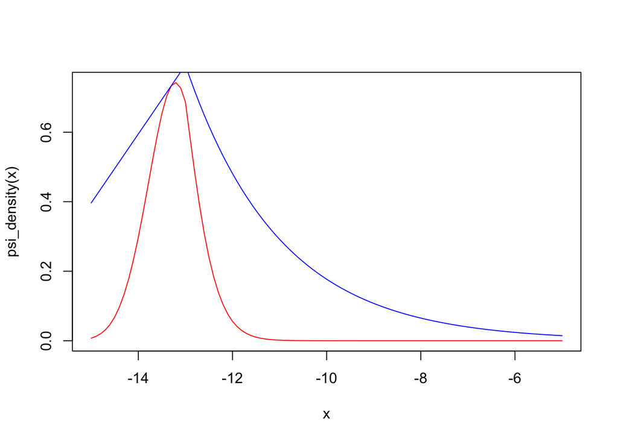

```r
curve(psi_density, add = FALSE, col = 'red', xlim = c(-15,-5))
curve(g_density_m, add = TRUE, col = 'blue', xlim = c(-15,-5))
```

Cela confirme que l’on a pris un M très proche de la meilleure valeur possible. On aurait pu en trouver u très légèrement meilleur en analysant explicitement la fonction G(x)*(1-G(x)), mais les calculs numériques montrent que le changement aurait été infime

2. Vérification de l’algo de rejet

```r
hist(rejet(1000000),  freq = FALSE, breaks = 1000, col = 'blue', plot = TRUE)
```

```
## [1] 0
```

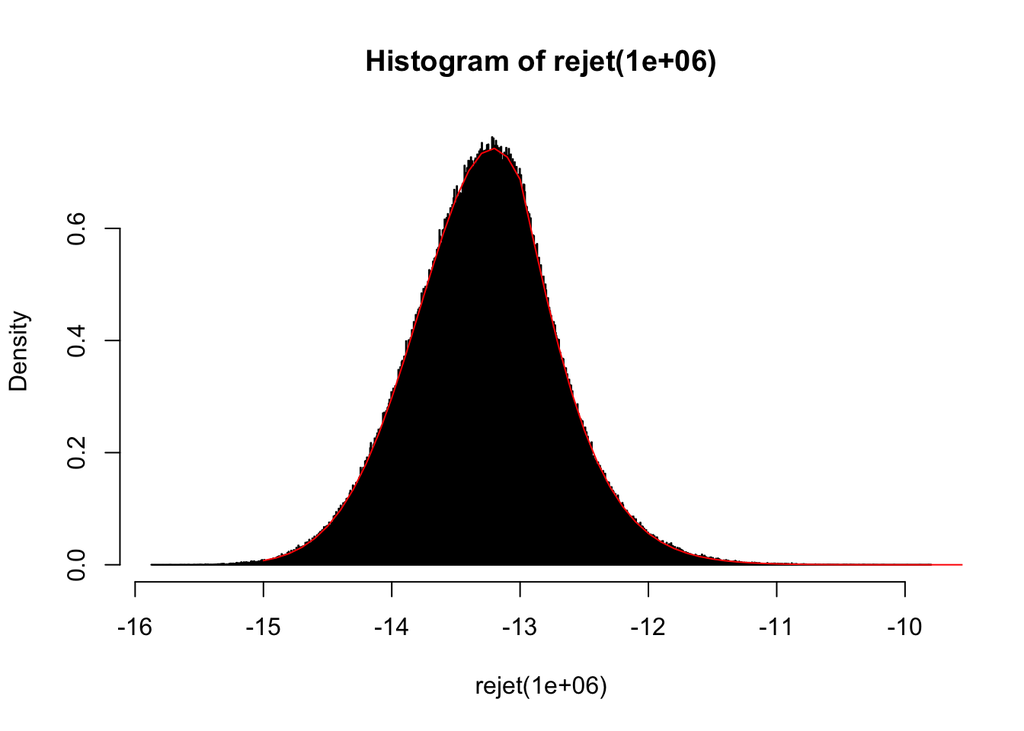

```r
curve(psi_density, add = TRUE, col = 'red', xlim = c(-15,-5))
```

On obtient bien un histogramme, qui suit la densité de $\Psi$.